# Оптимизация. Введение

У нас есть набор наблюдений о нескольких клиентах страховой компании:

стаж (кол-во лет за рулем) - $x_1$, доход - $x_2$, кол-во страховых выплат $y$

Необходимо подобрать такие коэффициенты $a_1$, $a_2$ для $x_1$ и $x_2$, чтобы полученная модель максимально точно предсказывала количество страховых выплат за год.

```python
import numpy as np
import pandas as pd
from scipy import optimize
from scipy import stats
import matplotlib.pyplot as plt
import seaborn as sns
```

```python
data = np.array([
    [3, 30000, 2],
    [10, 65000, 0],
    [6, 15000, 1],
    [12, 53000, 0],
    [1, 70000, 0],
    [3, 45000, 1],
    [4, 25000, 0],
    [1, 20000, 2]
])
```

### Посчитаем корреляцию каждого из факторов с целевым значением

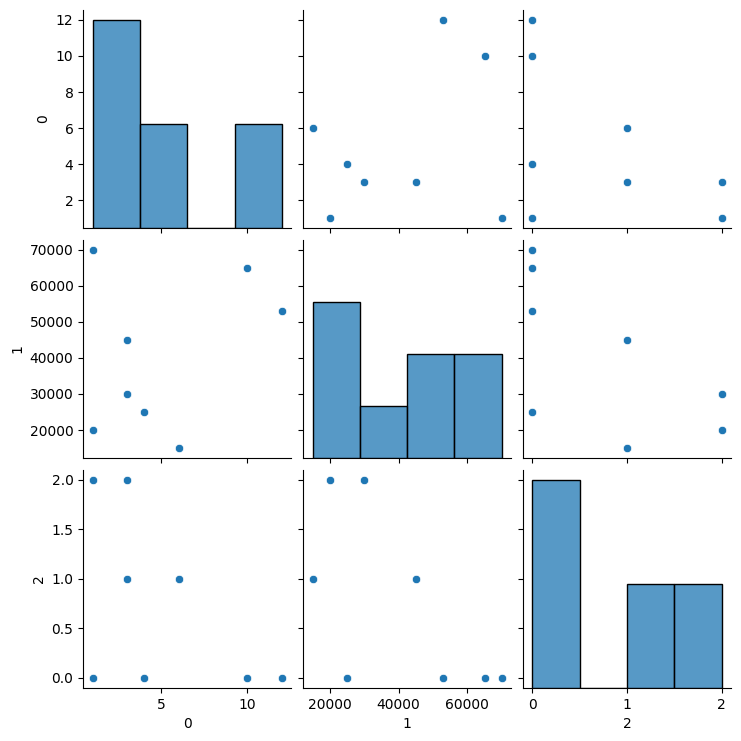

```python
sns.pairplot(pd.DataFrame(data))
```

```python
data[:, 0]
```

```
array([ 3, 10,  6, 12,  1,  3,  4,  1])
```

```python
data[:, 1]
```

```
array([30000, 65000, 15000, 53000, 70000, 45000, 25000, 20000])
```

```python
stats.pearsonr(data[:, 1], data[:, 2])[0]
```

```
-0.633192455625601
```

```python
stats.pearsonr(data[:, 0], data[:, 2])[0]
```

```
-0.5146749286021823
```

```python
from mpl_toolkits.mplot3d import Axes3D
import matplotlib.pyplot as plt
from matplotlib import cm
from matplotlib.ticker import LinearLocator, FormatStrFormatter
```

### Loss-функция "абсолютная ошибка"

MAE (Mean Absolute Error)

[figure not shown]

```python
def loss_func(A1, A2, data):
    return np.sum([np.abs(A1 * data[:, 0][d] + A2 * data[:, 1][d] + 2.29 - data[:, 2][d])
                   for d in range(len(data[:, 0]))], axis=0)
```

### Разберем подробнее

```python
np.arange(-3e-5, -1e-5, 1e-6)
```

```
array([-3.0e-05, -2.9e-05, -2.8e-05, -2.7e-05, -2.6e-05, -2.5e-05,
       -2.4e-05, -2.3e-05, -2.2e-05, -2.1e-05, -2.0e-05, -1.9e-05,
       -1.8e-05, -1.7e-05, -1.6e-05, -1.5e-05, -1.4e-05, -1.3e-05,
       -1.2e-05, -1.1e-05])
```

```python
A1 = np.arange(-0.15, 0, 0.001)
A2 = np.arange(-3e-5, -1e-5, 1e-6)
```

```python
A1.shape,A2.shape
```

```
((150,), (20,))
```

```python
A1, A2 = np.meshgrid(A1, A2)
```

```python
A1.shape,A2.shape
```

```
((20, 150), (20, 150))
```

```python
A1
```

```
array([[-0.15 , -0.149, -0.148, ..., -0.003, -0.002, -0.001],
       [-0.15 , -0.149, -0.148, ..., -0.003, -0.002, -0.001],
       [-0.15 , -0.149, -0.148, ..., -0.003, -0.002, -0.001],
       ...,
       [-0.15 , -0.149, -0.148, ..., -0.003, -0.002, -0.001],
       [-0.15 , -0.149, -0.148, ..., -0.003, -0.002, -0.001],
       [-0.15 , -0.149, -0.148, ..., -0.003, -0.002, -0.001]])
```

```python
A2
```

```
array([[-3.0e-05, -3.0e-05, -3.0e-05, ..., -3.0e-05, -3.0e-05, -3.0e-05],
       [-2.9e-05, -2.9e-05, -2.9e-05, ..., -2.9e-05, -2.9e-05, -2.9e-05],
       [-2.8e-05, -2.8e-05, -2.8e-05, ..., -2.8e-05, -2.8e-05, -2.8e-05],
       ...,
       [-1.3e-05, -1.3e-05, -1.3e-05, ..., -1.3e-05, -1.3e-05, -1.3e-05],
       [-1.2e-05, -1.2e-05, -1.2e-05, ..., -1.2e-05, -1.2e-05, -1.2e-05],
       [-1.1e-05, -1.1e-05, -1.1e-05, ..., -1.1e-05, -1.1e-05, -1.1e-05]])
```

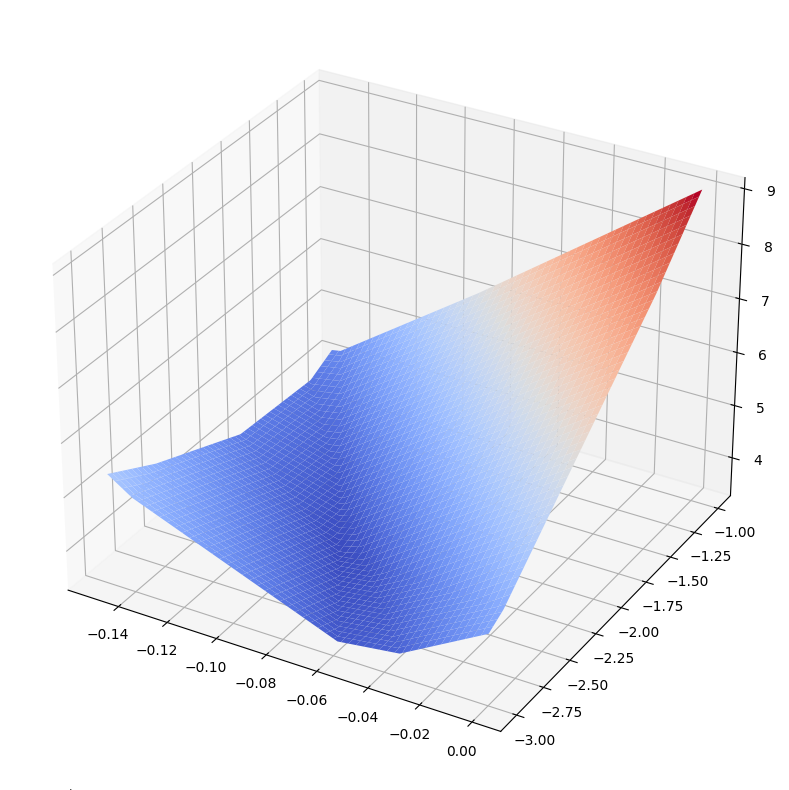

```python
# Настраиваем 3D график
#fig = plt.figure(figsize=[15, 10])
#ax = fig.gca()

fig = plt.figure(figsize=[15, 10])
ax = fig.add_subplot(111, projection='3d')

# Задаем угол обзора
#ax.view_init(40, -50)

# Создаем данные для графика
A1 = np.arange(-0.15, 0, 0.0001)
A2 = np.arange(-3e-5, -1e-5, 1e-7)
A1, A2 = np.meshgrid(A1, A2)
Z = loss_func(A1, A2, data)

# Рисуем поверхность
surf = ax.plot_surface(A1, A2, Z, cmap=cm.coolwarm)
plt.show()
```

### Loss-функция "квадратичная ошибка"

MSE (Mean Squared Error)

[figure not shown]

```python
def loss_func_sq(A1, A2, data):
    return np.sum([(A1 * data[:, 0][d] + A2 * data[:, 1][d] + 2.29 - data[:, 2][d])**2
                   for d in range(len(data[:, 0]))], axis=0)
```

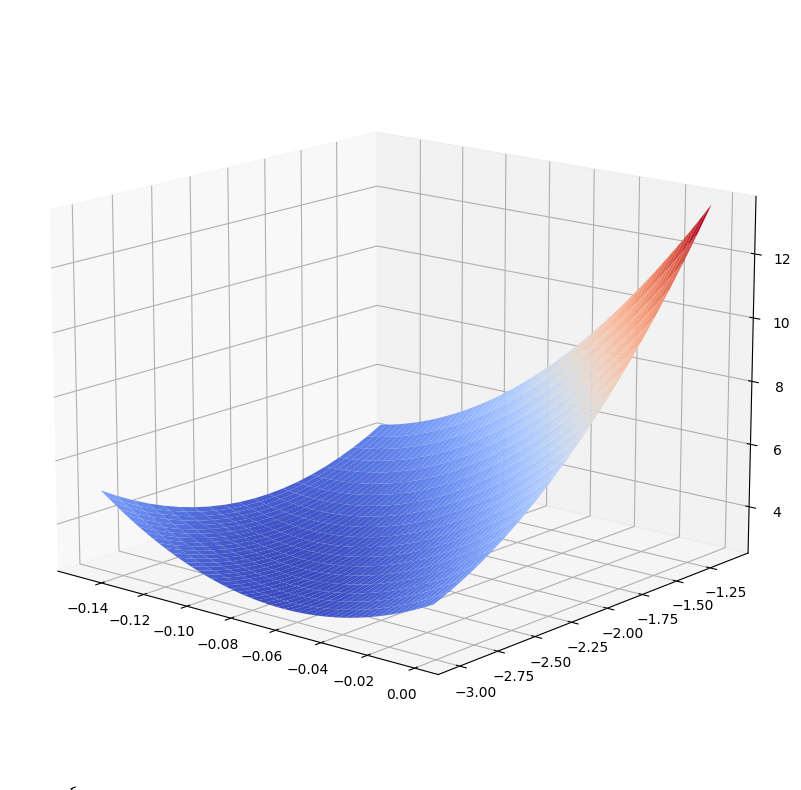

```python
# Настраиваем 3D график
#fig = plt.figure(figsize=[15, 10])
#ax = fig.gca(projection='3d')

fig = plt.figure(figsize=[15, 10])
ax = fig.add_subplot(111, projection='3d')

# Задаем угол обзора
ax.view_init(15, -50)

# Создаем данные для графика
A1 = np.arange(-0.15, 0, 0.001)
A2 = np.arange(-3e-5, -1e-5, 1e-6)
A1, A2 = np.meshgrid(A1, A2)
Z = loss_func_sq(A1, A2, data)

# Рисуем поверхность
surf = ax.plot_surface(A1, A2, Z, cmap=cm.coolwarm)
plt.show()
```

## Теперь оптимизация коэффициентов

```python
def func(a):
    errors = []
    for row in data:
        errors.append(abs(row[0]*a[0] + row[1]*a[1] + a[2] - row[2]))
    return sum(errors)

def func_exp(a):
    errors = []
    for row in data:
        errors.append(abs(row[0]*a[0] + row[1]*a[1] + a[2] - row[2]))
#         print(row[0]*a[0] + row[1]*a[1] + a[2])
    return sum(errors)
```

## Алгоритмы оптимизации

### Градиент функции

https://habr.com/ru/post/413853/

На предыдущем занятии мы выяснили, что если функция дифференцируема, то градиент (производная, в случае одномерной функции) равен 0 в точке оптимума (минимум/максимум). А вот несет ли градиент какую-нибудь полезную информацию в случае, когда он отличен от нуля?

Если $\nabla f(x)\neq 0$, то градиент указывает направление наибольшего локального увеличения функции.

Вот два примера для двумерных функций. Такого рода картинки можно часто увидеть в демонстрациях градиентного спуска. Цветные линии — так называемые линии уровня, это множество точек, для которых функция принимает фиксированное значений, в моем случае это круги и эллипсы. Я обозначил синими линии уровня с более низким значением, красными — с более высоким.

[figure not shown]

### Методы

**BFGS** (и его модификация L-BFGS-B)

- Использует расчет градиента
- Не рассчитывает в явном виде вторые производные (за счет этого работает быстрее)
- Применим хорошо для дифференцируемых выпуклых функций потерь.

https://habr.com/ru/post/333356/

**SLSQP**

- Разновидность метода наименьших квадратов
- Не использует расчет градиента в явном виде (использует методы Ньютона для приближения значения экстремума).
- Применим как для дифференцируемых, так и для недифференцируемых на некоторых отрезках функций потерь.
- Можно использовать как границы, так и сложные условные ограничения для поиска оптимизации в ограниченном пространстве

### Здесь будет отсутствие сходимости алгоритма

```python
res = optimize.minimize(func, [0, 0, 0], method='BFGS')

print(res)
```

```
  message: Desired error not necessarily achieved due to precision loss.
  success: False
   status: 2
      fun: 6.0
        x: [ 0.000e+00  0.000e+00  0.000e+00]
      nit: 0
      jac: [ 1.400e+01  1.030e+05  0.000e+00]
 hess_inv: [[1 0 0]
            [0 1 0]
            [0 0 1]]
     nfev: 376
     njev: 91
```

### А вот SLSQP сработает без проблем

```python
res = optimize.minimize(func, [0, 0, 0], method='SLSQP')

print(res)
```

```
 message: Optimization terminated successfully
 success: True
  status: 0
     fun: 3.411106787133437
       x: [-8.160e-02 -3.313e-05  2.735e+00]
     nit: 21
     jac: [-1.800e+01  1.374e+03 -2.000e+00]
    nfev: 130
    njev: 21
```

```python
res = optimize.minimize(func, [0, 5, 15], method='SLSQP')

print(res)
```

```
 message: Optimization terminated successfully
 success: True
  status: 0
     fun: 3.415006688007894
       x: [-8.119e-02 -3.261e-05  2.703e+00]
     nit: 29
     jac: [-1.800e+01  2.325e+03 -2.000e+00]
    nfev: 208
    njev: 29
```

### Посмотрим теперь на функцию зависимости целевого параметра от 2-х наших факторов

```python
def func_exec(X, Y, a):
    return a[0] * X + a[1] * Y + a[2]
```

```python
res.x
```

```
array([-8.11932709e-02, -3.26145832e-05,  2.70288713e+00])
```

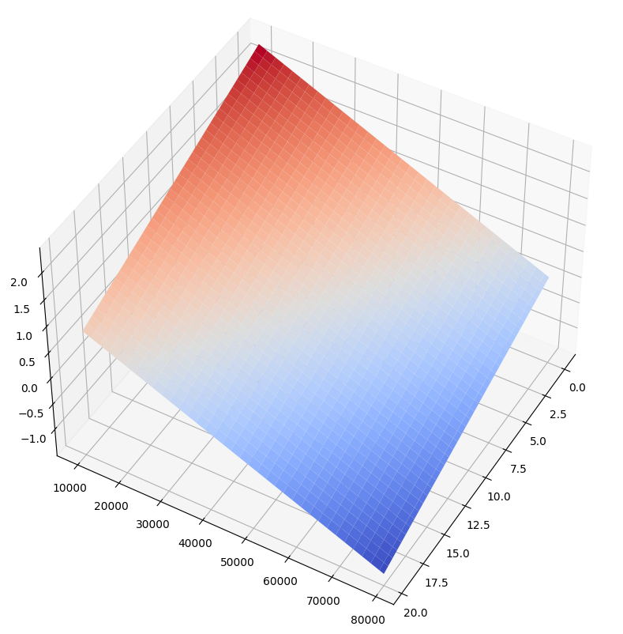

```python
# Настраиваем 3D график
#fig = plt.figure(figsize=[15, 10])
#ax = fig.gca(projection='3d')

fig = plt.figure(figsize=[15, 10])
ax = fig.add_subplot(111, projection='3d')

# Задаем угол обзора
ax.view_init(45, 30)

# Создаем данные для графика
X = np.arange(0, 20, 0.5)
Y = np.arange(10000, 80000, 1000)
X, Y = np.meshgrid(X, Y)
# print(np.array([X,Y]))
Z = func_exec(X, Y, res.x)

# Рисуем поверхность
surf = ax.plot_surface(X, Y, Z, cmap=cm.coolwarm)
plt.show()
```

### Шикарная линейная плоскость

```python
# Повторим аналогично, но для квадратичной функции потерь
```

```python
def func_mse(a):
    errors = []
    for row in data:
        errors.append((row[0]*a[0] + row[1]*a[1] + a[2] - row[2])**2)
    return sum(errors)
```

```python
res1 = optimize.minimize(func_mse, [0, 0, 0], method='BFGS')

print(res1)
```

```
  message: Optimization terminated successfully.
  success: True
   status: 0
      fun: 2.6472835150500127
        x: [-7.813e-02 -2.237e-05  2.044e+00]
      nit: 5
      jac: [-9.716e-06 -2.980e-08  4.172e-07]
 hess_inv: [[ 4.726e-03 -2.708e-07 -1.270e-02]
            [-2.708e-07  1.785e-10 -5.854e-06]
            [-1.270e-02 -5.854e-06  3.623e-01]]
     nfev: 28
     njev: 7
```

```python
RMSE = np.sqrt(res1.fun)
```

```python
print(RMSE)
```

```
1.6270474839978182
```

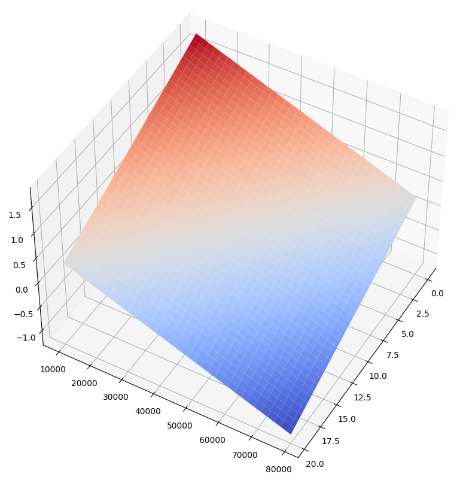

```python
# Настраиваем 3D график
#fig = plt.figure(figsize=[15, 10])
#ax = fig.gca(projection='3d')

fig = plt.figure(figsize=[15, 10])
ax = fig.add_subplot(111, projection='3d')

# Задаем угол обзора
ax.view_init(45, 30)

# Создаем данные для графика
X = np.arange(0, 20, 0.5)
Y = np.arange(10000, 80000, 1000)
X, Y = np.meshgrid(X, Y)
# print(np.array([X,Y]))
Z = func_exec(X, Y, res1.x)

# Рисуем поверхность
surf = ax.plot_surface(X, Y, Z, cmap=cm.coolwarm)
plt.show()
```

```python
from sklearn.metrics import mean_squared_error, mean_absolute_error
```

```python
# функция ошибки при оптимизации MAE
mean_squared_error(data[:, 2],
                   func_exec(data[:, 0], data[:,1], res.x)),\
mean_absolute_error(data[:, 2],
                   func_exec(data[:, 0], data[:,1], res.x))
```

```
(0.42595504714124466, 0.4268758360009868)
```

```python
# функция ошибки при оптимизации MSE
mean_squared_error(data[:, 2],
                   func_exec(data[:, 0], data[:,1], res1.x)),\
mean_absolute_error(data[:, 2],
                   func_exec(data[:, 0], data[:,1], res1.x))
```

```
(0.3309104393812516, 0.4528408744658433)
```

## Пример оптимизации с ограничениями

В связи с переходом к пятому технологическому укладу, рассмотрим оптимизацию производства на примере веб-студии, которая приносит нам небольшой, но стабильный доход. Представим себя директором галеры, на которой производится три вида продукции:

- x0 — продающие лэндинги, от 10 т.р.
- x1 — корпоративные сайты, от 20 т.р.
- x2 — интернет магазины, от 30 т.р.

Наш дружный рабочий коллектив включает в себя четырех джунов, двух мидлов и одного сеньора. Фонд их рабочего времени на месяц:

джуны: 4 * 150 = 600 чел * час, мидлы: 2 * 150 = 300 чел * час, сеньор: 150 чел * час.

Пусть на разработку и деплой одного сайта типа (x0, x1, x2) первый попавшийся джуниор должен потратить (10, 20, 30) часов, мидл — (7, 15, 20), сеньор — (5, 10, 15) часов лучшего времени своей жизни.

Как любому нормальному директору, нам хочется максимизировать ежемесячную прибыль. Первый шаг к успеху — записываем целевую функцию value как сумму доходов от произведенной за месяц продукции:

```python
jun = np.array([10,20,30])
mid = np.array([7,15,20])
sen = np.array([5,10,15])
```

```python
def value(x):
    return (-1) * (10*x[0] + 20*x[1] + 30*x[2])
```

Это не ошибка, при поиске максимума целевая функция минимизируется с обратным знаком.

Следующий шаг — запрещаем перерабатывать своим сотрудникам и вводим ограничения на фонд рабочего времени:

$$\begin{bmatrix} 10 & 20 & 30 \\ 7 & 15 & 20 \\ 5 & 10 & 15 \end{bmatrix} \begin{bmatrix} x_0 \\ x_1 \\ x_2 \end{bmatrix} \leq \begin{bmatrix} 600 \\ 300 \\ 150 \end{bmatrix}$$

```python
ineq_cons = {'type': 'ineq',
             'fun': lambda x: np.array ([600 - 10 * x [0] - 20 * x [1] - 30 * x[2],
                                         300 - 7  * x [0] - 15 * x [1] - 20 * x[2],
                                         150 - 5  * x [0] - 10 * x [1] - 15 * x[2]])
            }
```

Формальное ограничение — выпуск продукции должен быть только положительным:

```python
bnds = optimize.Bounds([0, 0, 0], [np.inf, np.inf, np.inf])
```

И наконец самое радужное допущение — из-за низкой цены и высокого качества к нам постоянно выстраивается очередь из довольных клиентов. Мы можем сами выбирать ежемесячные объемы производства продукции, исходя из решения задачи условной оптимизации с scipy.optimize:

```python
x0 = np.array([10, 10, 10])
res = optimize.minimize(value, x0, method='SLSQP', constraints=ineq_cons, bounds=bnds)
print(res)
```

```
 message: Optimization terminated successfully
 success: True
  status: 0
     fun: -299.9999999988218
       x: [ 7.857e+00  5.714e+00  3.571e+00]
     nit: 2
     jac: [-1.000e+01 -2.000e+01 -3.000e+01]
    nfev: 8
    njev: 2
```

### Вычислим загрузку каждого из типов сотрудников

Предварительно нестрого округлим получившиеся оптимальные значения

```python
value([7.85714286, 5.71428571, 3.57142857])
```

```
-299.9999999
```

```python
result = np.array([*map(int,res.x)])
```

```python
print("Джуны: {0}".format(result@jun))

print("Мидлы: {0}".format(result@mid))

print("Сеньор: {0}".format(result@sen))
```

```
Джуны: 260
Мидлы: 184
Сеньор: 130
```